# Analysis of storms impact on population health and economy in US

Georgy Makarov

April 21, 2020

## Synopsis

Storms cause public health and economic problems in US. Preventing fatalities, injuries and asset loss are major concern for local authorities.

The goal of this analysis was to identify the most hazardous weather events in terms of population health and economy in US. This analysis is based on US National Oceanic and Atmospheric Administration data covering events from 1950 to 2011.

The analysis shows that the most harmful event for population health is tornado. The most harmful event for economy is flood.

## Prerequisite packages

This analysis used four packages: *reshape2, dplyr, lubridate, ggplot2*.

```r
library(reshape2)
library(dplyr)
library(lubridate)
library(ggplot2)
```

## Load data

Data from NOAA is available from cloud storage here. Data description is here. More information about the storm is available in FAQ.

The approach to loading the data is to download compressed file from URL if not found in working directory. Then load the data using *read.csv* and validate the data by checking the file size and data dimensions, which are available in supporting forum.

```r
raw_data_url <- "http://d396qusza40orc.cloudfront.net/repdata%2Fdata%2FStormData.csv.bz2"
if (!file.exists("repdata_data_StormData.csv.bz2")) {
    download.file(url = raw_data_url,
                  destfile = "repdata_data_StormData.csv.bz2")
    }

file_info <- file.info("repdata_data_StormData.csv.bz2")
storm_data <- read.csv("repdata_data_StormData.csv.bz2", sep = ",", header = TRUE)

stopifnot(file_info[,1] == 49177144)
stopifnot(dim(storm_data) == c(902297,37))
```

## Data processing

### Subsetting dataset

There are seven total variables required to perform this analysis: event type, fatalities, injuries, damage to property, property damage multiplier, crop damage, crop damage multiplier. Those can be obtained from the names of the variables in the raw data.

```r
names(storm_data)
```

```
##  [1] "STATE__"    "BGN_DATE"   "BGN_TIME"   "TIME_ZONE"  "COUNTY"
##  [6] "COUNTYNAME" "STATE"      "EVTYPE"     "BGN_RANGE"  "BGN_AZI"
## [11] "BGN_LOCATI" "END_DATE"   "END_TIME"   "COUNTY_END" "COUNTYENDN"
## [16] "END_RANGE"  "END_AZI"    "END_LOCATI" "LENGTH"     "WIDTH"
## [21] "F"          "MAG"        "FATALITIES" "INJURIES"   "PROPDMG"
## [26] "PROPDMGEXP" "CROPDMG"    "CROPDMGEXP" "WFO"        "STATEOFFIC"
## [31] "ZONENAMES"  "LATITUDE"   "LONGITUDE"  "LATITUDE_E" "LONGITUDE_"
## [36] "REMARKS"    "REFNUM"
```

The list of necessary variables follows:  
- EVTYPE - event type;  
- FATALITIES - number of fatalities in event;  
- INJURIES - number of injuries in event;  
- PROPDMG - property damage;  
- PROPDMGEXP - property damage multiplier;  
- CROPDMG - crop damage;  
- CROPDMGEXP - crop damage multiplier.

The dataset is reduced to these variables.

```r
subset_data1 <- storm_data %>%
    select(event_type = EVTYPE,
           fatalities = FATALITIES,
           injuries = INJURIES,
           property_damage = PROPDMG,
           property_multiplier = PROPDMGEXP,
           crop_damage = CROPDMG,
           crop_multiplier = CROPDMGEXP)
```

Part of observations contains event type *NONE* - we kick those observations. Additionally, we only need observations with values greater than zero.

```r
subset_data2 <- subset_data1 %>%
    filter(fatalities >0 | injuries > 0 |
               property_damage > 0 | crop_damage > 0 & event_type != "NONE")
```

The subset has reduced to 254633 rows. Check that there are no missiong values in the subset.

```r
dim(subset_data2)
```

```
## [1] 254633      7
```

```r
sum(complete.cases(subset_data2))
```

```
## [1] 254633
```

### Modifying event type

The official events type are 48. The subset contains 488 unique events type.

```r
length(unique(subset_data2$event_type))
```

```
## [1] 488
```

The reason behind large number of types is that the dataset contains typos and similar events in capital letters like: *wind* and *WIND*.

```r
unique(subset_data2$event_type)
```

```
##   [1] TORNADO                        TSTM WIND
##   [3] HAIL                           ICE STORM/FLASH FLOOD
##   [5] WINTER STORM                   HURRICANE OPAL/HIGH WINDS
##   [7] THUNDERSTORM WINDS             HURRICANE ERIN
##   [9] HURRICANE OPAL                 HEAVY RAIN
##  [11] LIGHTNING                      THUNDERSTORM WIND
##  [13] DENSE FOG                      RIP CURRENT
##  [15] THUNDERSTORM WINS              FLASH FLOODING
##  [17] FLASH FLOOD                    TORNADO F0
##  [19] THUNDERSTORM WINDS LIGHTNING   THUNDERSTORM WINDS/HAIL
##  [21] HEAT                           HIGH WINDS
##  [23] WIND                           HEAVY RAINS
##  [25] LIGHTNING AND HEAVY RAIN       THUNDERSTORM WINDS HAIL
##  [27] COLD                           HEAVY RAIN/LIGHTNING
##  [29] FLASH FLOODING/THUNDERSTORM WI FLOODING
```

[output cut: 230 more lines]

One way to solve this problem is to convert all event types to lowercase characters. This action reduced the number of event types to 447.

```r
subset_data3 <- subset_data2 %>%
    mutate(event_type = tolower(event_type))
length(unique(subset_data3$event_type))
```

```
## [1] 447
```

Further reduction of the dataset is acheived by grouping the events type using the key word from the official event type names. The events that do not match any key word are grouped into *other*.

```r
subset_data3$event <- "other"
subset_data3$event[grep("avalanche", subset_data3$event_type)] <- "avalanche"
subset_data3$event[grep("blizzard", subset_data3$event_type)] <- "snow"
subset_data3$event[grep("flood", subset_data3$event_type)] <- "flood"
subset_data3$event[grep("wind", subset_data3$event_type)] <- "wind"
subset_data3$event[grep("fog", subset_data3$event_type)] <- "fog"
subset_data3$event[grep("cold", subset_data3$event_type)] <- "cold"
subset_data3$event[grep("chill", subset_data3$event_type)] <- "cold"
subset_data3$event[grep("frost", subset_data3$event_type)] <- "cold"
subset_data3$event[grep("freeze", subset_data3$event_type)] <- "cold"
subset_data3$event[grep("tornado", subset_data3$event_type)] <- "tornado"
subset_data3$event[grep("hail", subset_data3$event_type)] <- "hail"
subset_data3$event[grep("winds", subset_data3$event_type)] <- "wind"
subset_data3$event[grep("win", subset_data3$event_type)] <- "wind"
subset_data3$event[grep("wins", subset_data3$event_type)] <- "wind"
subset_data3$event[grep("storm", subset_data3$event_type)] <- "storm"
subset_data3$event[grep("rainstorm", subset_data3$event_type)] <- "storm"
subset_data3$event[grep("thunderstorm", subset_data3$event_type)] <- "storm"
subset_data3$event[grep("snow", subset_data3$event_type)] <- "snow"
subset_data3$event[grep("rain", subset_data3$event_type)] <- "rain"
subset_data3$event[grep("heat", subset_data3$event_type)] <- "heat"
subset_data3$event[grep("hurricane", subset_data3$event_type)] <- "hurricane"
subset_data3$event[grep("fld", subset_data3$event_type)] <- "flood"
subset_data3$event[grep("current", subset_data3$event_type)] <- "waves"
subset_data3$event[grep("surf", subset_data3$event_type)] <- "waves"
subset_data3$event[grep("fire", subset_data3$event_type)] <- "fire"
subset_data3$event[grep("water", subset_data3$event_type)] <- "flood"
subset_data3$event[grep("wave", subset_data3$event_type)] <- "waves"
subset_data3$event[grep("tsunami", subset_data3$event_type)] <- "waves"
subset_data3$event[grep("lightning", subset_data3$event_type)] <- "storm"
subset_data3$event[grep("warm", subset_data3$event_type)] <- "heat"
subset_data3$event[grep("torndao", subset_data3$event_type)] <- "tornado"
subset_data3$event[grep("high tides", subset_data3$event_type)] <- "waves"
subset_data3$event[grep("high seas", subset_data3$event_type)] <- "waves"
subset_data3$event[grep("marine mishap", subset_data3$event_type)] <- "waves"
subset_data3$event[grep("slide", subset_data3$event_type)] <- "slides"
subset_data3$event[grep("dust devil", subset_data3$event_type)] <- "heat"
subset_data3$event[grep("dry microburst", subset_data3$event_type)] <- "heat"
subset_data3$event[grep("low temperature", subset_data3$event_type)] <- "cold"
subset_data3$event[grep("freezing spray", subset_data3$event_type)] <- "cold"
subset_data3$event[grep("dam break", subset_data3$event_type)] <- "flood"
```

This operation has reduced the dataset events type to 16 unique values.

```r
length(unique(subset_data3$event))
```

```
## [1] 16
```

Top-10 events type by the number of rows cover 99% of all observations.

```r
sum(sort(table(subset_data3$event), decreasing = TRUE)[1:10]) / nrow(subset_data3)
```

```
## [1] 0.9927072
```

The dataset is reduced to top-10 events.

```r
sum(sort(table(subset_data3$event), decreasing = TRUE)[1:10])
```

```
## [1] 252776
```

```r
sort(table(subset_data3$event), decreasing = TRUE)[1:10]
```

```
##
##    wind   storm tornado   flood    hail    snow    fire    rain    heat   waves
##   74491   72246   39961   33223   26157    2134    1258    1246    1126     934
```

```r
subset_data4 <- subset_data3 %>%
    filter(event %in% c("wind", "storm", "tornado", "flood", "hail", "snow",
                        "fire", "rain", "heat", "waves"))
dim(subset_data4)
```

```
## [1] 252776      8
```

### Cleaning units

Property damage multiplier and crop damage multiplier contain different units.

```r
unique(subset_data4$property_multiplier)
```

```
##  [1] K M   B + 0 5 m 6 4 h 2 7 3 H -
## Levels:  - ? + 0 1 2 3 4 5 6 7 8 B h H K m M
```

```r
unique(subset_data4$crop_multiplier)
```

```
## [1]   K M B ? 0 k
## Levels:  ? 0 2 B k K m M
```

Some units like k or K, m or M, B reflect thousands, millions and billions of USD. Numbers from 1 to 8 show the power coefficient for the multiplier like:
$$e = 10^k$$

where $ e $ is multiplier and $ k $ is from 1 to 8.

Other symbols do not transform to currency directly. For the purpose of this analysis those symbols are condidered to be 1 USD.

```r
subset_data5 <- subset_data4 %>%
    mutate(property_multiplier = tolower(property_multiplier),
           crop_multiplier = tolower(crop_multiplier))

subset_data5$property_multiplier <- as.character(subset_data5$property_multiplier)
subset_data5$property_multiplier[is.na(subset_data5$property_multiplier)] <- 0
subset_data5$property_multiplier[!grepl("k|m|b|h|2|3|4|5|6|7", subset_data5$property_multiplier)] <- 0
subset_data5$property_multiplier[grep("k", subset_data5$property_multiplier)] <- "3"
subset_data5$property_multiplier[grep("m", subset_data5$property_multiplier)] <- "6"
subset_data5$property_multiplier[grep("b", subset_data5$property_multiplier)] <- "9"
subset_data5$property_multiplier[grep("h", subset_data5$property_multiplier)] <- "2"

subset_data5$crop_multiplier <- as.character(subset_data5$crop_multiplier)
subset_data5$crop_multiplier[is.na(subset_data5$crop_multiplier)] <- 0
subset_data5$crop_multiplier[!grepl("k|m|b|h|2|3|4|5|6|7", subset_data5$crop_multiplier)] <- 0
subset_data5$crop_multiplier[grep("k", subset_data5$crop_multiplier)] <- "3"
subset_data5$crop_multiplier[grep("m", subset_data5$crop_multiplier)] <- "6"
subset_data5$crop_multiplier[grep("b", subset_data5$crop_multiplier)] <- "9"
subset_data5$crop_multiplier[grep("h", subset_data5$crop_multiplier)] <- "2"

subset_data5$property_multiplier <- as.numeric(as.character(subset_data5$property_multiplier))
subset_data5$crop_multiplier <- as.numeric(as.character(subset_data5$crop_multiplier))

subset_data5 <- subset_data5 %>%
    mutate(prop_damage = property_damage * 10^property_multiplier,
           crop_damage = crop_damage * 10^crop_multiplier) %>%
    select(event, fatalities, injuries, crop_damage, prop_damage)

head(subset_data5)
```

```
##     event fatalities injuries crop_damage prop_damage
## 1 tornado          0       15           0       25000
## 2 tornado          0        0           0        2500
## 3 tornado          0        2           0       25000
## 4 tornado          0        2           0        2500
## 5 tornado          0        2           0        2500
## 6 tornado          0        6           0        2500
```

### Data aggregation by health and economic results

The data is aggregated by the type of event using *summarise* function resulting in 2 datasets: health and economic. Economic figures are transformed into billions.

```r
health_dt <- subset_data5 %>%
    group_by(event) %>% summarise(fatalities = sum(fatalities),
                                  injuries = sum(injuries))
fatal_h <- health_dt %>%
    select(event, result = fatalities) %>%
    mutate(type = "fatal")
injuries_h <- health_dt %>%
    select(event, result = injuries) %>%
    mutate(type = "injury")
health_dt <- rbind(fatal_h, injuries_h)
health_dt
```

```
## # A tibble: 20 x 3
##    event   result type
##    <chr>    <dbl> <chr>
##  1 fire        90 fatal
##  2 flood     1562 fatal
##  3 hail        15 fatal
##  4 heat      3002 fatal
##  5 rain       114 fatal
##  6 snow       265 fatal
##  7 storm     1450 fatal
##  8 tornado   5633 fatal
##  9 waves      968 fatal
## 10 wind      1291 fatal
## 11 fire      1608 injury
## 12 flood     8753 injury
## 13 hail      1371 injury
## 14 heat      8920 injury
## 15 rain       305 injury
## 16 snow      1969 injury
## 17 storm    11923 injury
## 18 tornado  91364 injury
## 19 waves     1313 injury
## 20 wind      9616 injury
```

```r
economic_dt <- subset_data5 %>%
    group_by(event) %>% summarise(crop_damage_bln = sum(crop_damage) / 1000000000,
                                  prop_damage_bln = sum(prop_damage) / 1000000000)
prop_econ <- economic_dt %>%
    select(event, result = prop_damage_bln) %>%
    mutate(type = "property damage")
crop_econ <- economic_dt %>%
    select(event, result = crop_damage_bln) %>%
    mutate(type = "crop damage")
economic_dt <- rbind(prop_econ, crop_econ)
economic_dt
```

```
## # A tibble: 20 x 3
##    event      result type
##    <chr>       <dbl> <chr>
##  1 fire      8.50    property damage
##  2 flood   168.      property damage
##  3 hail     15.7     property damage
##  4 heat      0.0171  property damage
##  5 rain      3.25    property damage
##  6 snow      1.68    property damage
##  7 storm    74.2     property damage
##  8 tornado  57.0     property damage
##  9 waves     0.271   property damage
## 10 wind     12.4     property damage
## 11 fire      0.403   crop damage
## 12 flood    12.3     crop damage
## 13 hail      3.05    crop damage
## 14 heat      0.899   crop damage
## 15 rain      0.918   crop damage
## 16 snow      0.247   crop damage
## 17 storm     6.42    crop damage
## 18 tornado   0.415   crop damage
## 19 waves     0.00712 crop damage
## 20 wind      1.41    crop damage
```

## Results

### Which type of events are most harmful to population health

Tornado is the most harmful event of all severe weather conditions in US. Total number of injuries and deaths is 96997, which is 7 times more than the storms.

```r
health_dts <- health_dt %>%
    group_by(event) %>% summarise(result = sum(result)) %>%
    arrange(desc(result))
health_dts
```

```
## # A tibble: 10 x 2
##    event   result
##    <chr>    <dbl>
##  1 tornado  96997
##  2 storm    13373
##  3 heat     11922
##  4 wind     10907
##  5 flood    10315
##  6 waves     2281
##  7 snow      2234
##  8 fire      1698
##  9 hail      1386
## 10 rain       419
```

Distribution of health impact is given in the figure below.

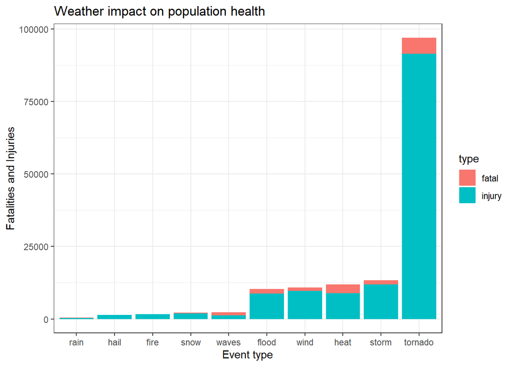

```r
ggplot(health_dt) +
    theme_bw() +
    ggtitle("Weather impact on population health") +
    xlab("Event type") + ylab("Fatalities and Injuries") +
    geom_col(aes(reorder(event, result), result, fill = type))
```

### Which types of events have the greatest economic consequences

In economic terms floods caused 181 bln USD loss, which makes them the most harmful event.

```r
economic_dts <- economic_dt %>%
    group_by(event) %>% summarise(result = sum(result)) %>%
    arrange(desc(result))
economic_dts
```

```
## # A tibble: 10 x 2
##    event    result
##    <chr>     <dbl>
##  1 flood   181.
##  2 storm    80.6
##  3 tornado  57.4
##  4 hail     18.8
##  5 wind     13.8
##  6 fire      8.90
##  7 rain      4.17
##  8 snow      1.93
##  9 heat      0.916
## 10 waves     0.278
```

Distribution of economic impact is given in the figure below.

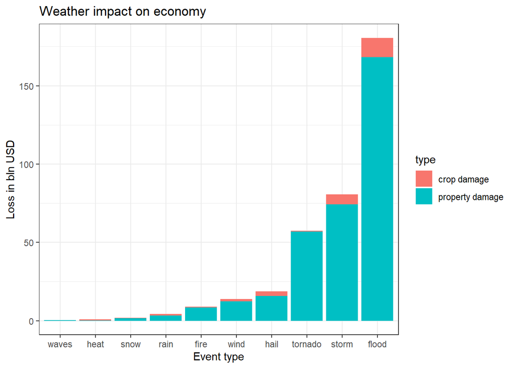

```r
ggplot(economic_dt) +
    theme_bw() +
    ggtitle("Weather impact on economy") +
    xlab("Event type") + ylab("Loss in bln USD") +
    geom_col(aes(reorder(event, result), result, fill = type))
```